# 数字图像处理作业——直线检测

自动化钱61 赵子瑞

2160405068

## 实验题目

1. 首先对测试图像（文件名为：test1~test6）进行边缘检测，可采用书上介绍的Sobel等模板或者cann算子方法；
2. 在边缘检测的基础上，用hough变换检测图中直线；
3. 比较不同边缘检测算法（2种以上）、不同hough变换参数对直线检测的影响；
4. 可以采用Matlab、OpenCV等自带函数。

## 边缘检测

边缘检测是基于灰度突变来分割图像的常用方法，从原理上来说，是基于图像的一阶导数或二阶导数来完成的。通过设计合理的梯度算子，我们可以得到相对较好的图像梯度分布，进而获得图像的边缘。

### 图像梯度

为了在一幅图像$f$的$(x,y)$位置处寻找边缘的强度和方向，所选择的工具就是梯度。梯度用$\nabla f$来表示，并用向量来定义：

$$ \nabla f\equiv grad(f)\equiv [g_x, g_y]^T = [\frac{\partial f}{\partial x}, \frac{\partial f}{\partial y}]^T $$ 该向量有一个重要的几何性质，即指出了$f$在位置$(x,y)$处的最大变化率的方向。

向量$\nabla f$的大小表示为$M(x,y)$，即 $$ M(x,y)=mag(\nabla f)=\sqrt{g_x^2+g_y^2} $$ 它是图像的梯度向量的变化率的值。

### 梯度算子

要得到一幅图像的梯度，要求在图像的每一个像素处计算偏导数$\partial f/ \partial x$和$\partial f /\partial y$处理的是数字量，因此要求关于一点的邻域上的偏导数的数字近似. $$ g_x=\frac{\partial f(x,y)}{\partial x}=f(x+1,y)-f(x,y) $$

$$ g_y=\frac{\partial f(x,y)}{\partial y}=f(x,y+1)-f(x,y) $$

Prewitt 模板 $$ g_x=\frac{\partial f(x,y)}{\partial x}=(z_7+z_8+z_9)-(z_1+z_2+z_3) $$

$$ g_y=\frac{\partial f(x,y)}{\partial x}=(z_3+z_6+z_9)-(z_1+z_4+z_7) $$

Sobel 模板

$$ g_x=\frac{\partial f(x,y)}{\partial x}=(z_7+2z_8+z_9)-(z_1+2z_2+z_3) $$

$$ g_y=\frac{\partial f(x,y)}{\partial x}=(z_3+2z_6+z_9)-(z_1+2z_4+z_7) $$

### Canny边缘检测器

Canny边缘检测器是迄今为止讨论过的最优秀的边缘检测器。Canny方法基于以下三个基本目标：

1. 低错误率。所有边缘都应该被找到，并且应该没有伪响应。也就是边缘检测应该是尽可能真实的边缘。
2. 边缘点应该被很好的定位。已经定位的边缘必须尽可能接近真实的边缘，也就是由检测器标记为边缘的点和真实的边缘的汇总新之间的距离应该最小。
3. 单一的边缘点响应。对于真实的边缘点，检测器仅应返回一个点。也就是真实的边缘周围的局部最大数应该是最小的。这意味着仅存在一个单一的边缘点检测位置，检测器不应该指出多个边缘像素。

Canny算子也存在不足之处:

1. 为了得到较好的边缘检测结果，它通常需要使用较大的滤波尺度，这样容易丢失一些细节
2. Canny算子的双阈值要人为的选取，不能够自适应

### 实验结果

实验结果如下所示

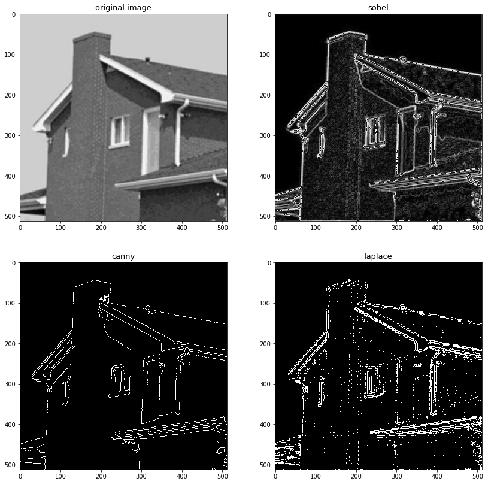

```python
import sys
import os
lib_path = os.path.abspath(os.path.join(sys.path[0], '..'))
sys.path.append(lib_path)
from src.basic_cv_tool import *

image_path = '../../homework7/project/'

def draw(img, img1, img2, img3):
    plt.figure(figsize = (14,14))
    p = plt.subplot(221)
    p.set_title('original image', fontsize = 13)
    p.imshow(img,cmap = 'gray')
    p1 = plt.subplot(222)
    p1.set_title('sobel', fontsize = 13)
    p1.imshow(img1,cmap='gray')
    p2 = plt.subplot(223)
    p2.set_title('canny', fontsize = 13)
    p2.imshow(img2,cmap='gray')
    p3 = plt.subplot(224)
    p3.set_title('laplace', fontsize = 13)
    p3.imshow(img3,cmap='gray')

image_name = '../../homework7/project/test1.tif'
tool = basic_cv_tool(image_name)
img = tool.ImageRead(image_name)
img1 = tool.sobel_filter(img)
img2 = tool.canny(img)
img3 = tool.laplace_filter(img)
draw(img, img1, img2, img3)
```

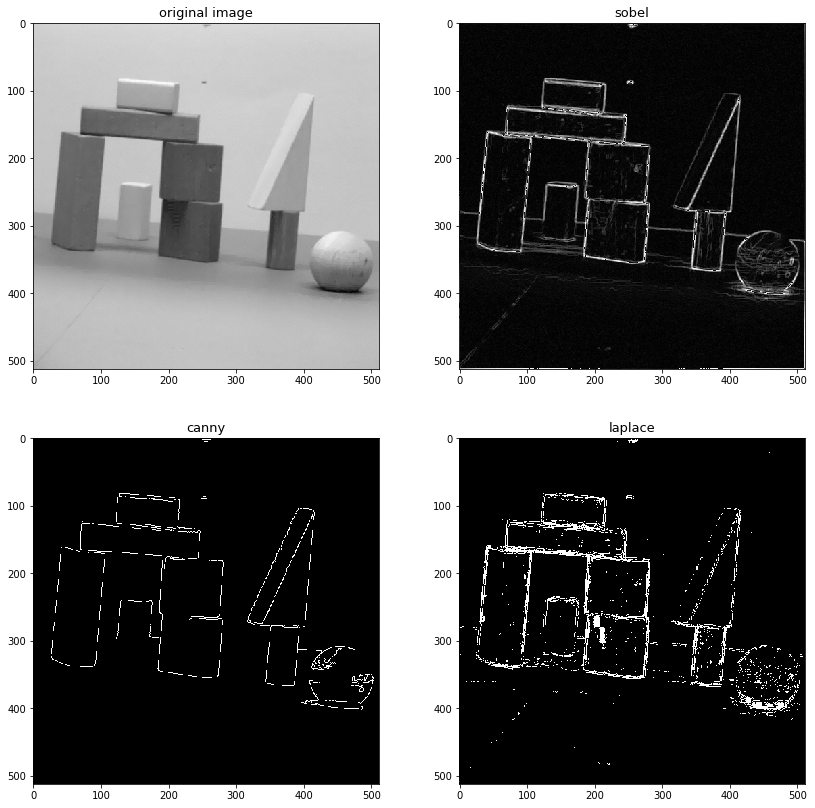

```python
image_name = '../../homework7/project/test2.png'
tool = basic_cv_tool(image_name)
img = tool.ImageRead(image_name)
img1 = tool.sobel_filter(img)
img2 = tool.canny(img)
img3 = tool.laplace_filter(img)
draw(img, img1, img2, img3)
```

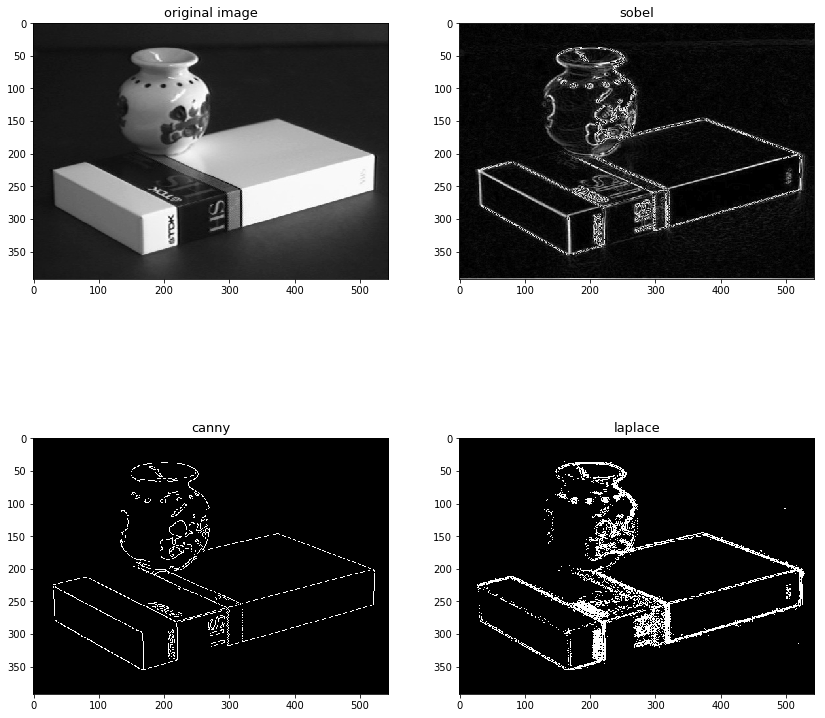

```python
image_name = '../../homework7/project/test3.jpg'
tool = basic_cv_tool(image_name)
img = tool.ImageRead(image_name)
img1 = tool.sobel_filter(img)
img2 = tool.canny(img)
img3 = tool.laplace_filter(img)
draw(img, img1, img2, img3)
```

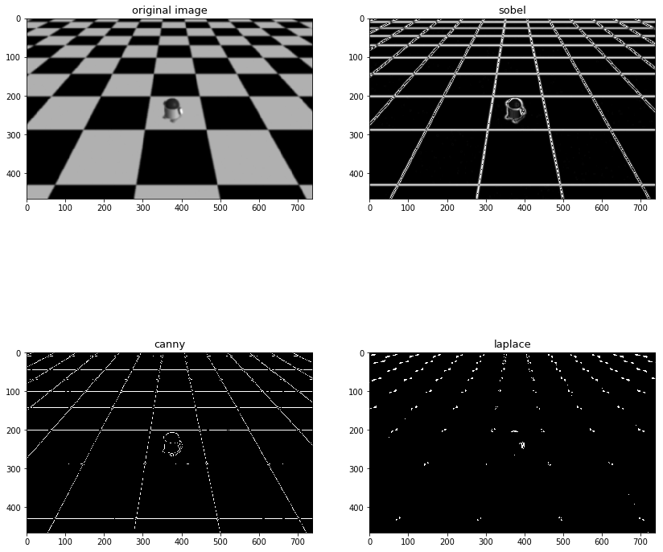

```python
image_name = '../../homework7/project/test4.bmp'
tool = basic_cv_tool(image_name)
img = tool.ImageRead(image_name)
img1 = tool.sobel_filter(img)
img2 = tool.canny(img)
img3 = tool.laplace_filter(img)
draw(img, img1, img2, img3)
```

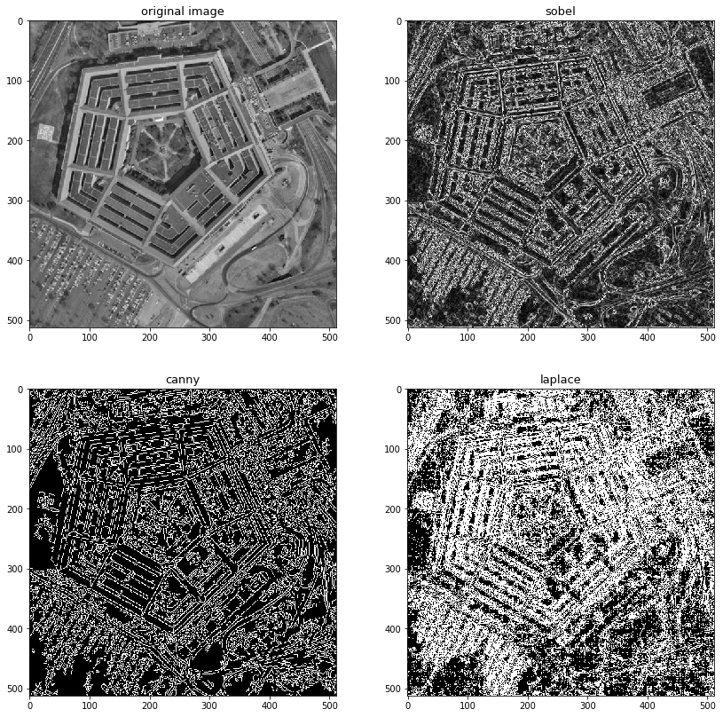

```python
image_name = '../../homework7/project/test5.png'
tool = basic_cv_tool(image_name)
img = tool.ImageRead(image_name)
img1 = tool.sobel_filter(img)
img2 = tool.canny(img)
img3 = tool.laplace_filter(img)
draw(img, img1, img2, img3)
```

[figure not shown]

```python
image_name = '../../homework7/project/test6.jpg'
tool = basic_cv_tool(image_name)
img = tool.ImageRead(image_name)
img1 = tool.sobel_filter(img)
img2 = tool.canny(img)
img3 = tool.laplace_filter(img)
draw(img, img1, img2, img3)
```

## 直线检测

直线检测是通过Hough变换实现的。Hough 变换是一种采用投票原理的参数估计技术。

其原理是利用图像空间的点线二重性和 Hough 参数空间将图像空间中的检测问题转换为参数空间。Hough 变换的原理是通过在参数空间中进行简单的累积统计, 然后在 Hough 参数空间中寻找蓄能器的峰值来检测直线。Hough 变换的实质是将具有一定关系的单元格聚集在图像空间中, 并找到与这些单元的某种解析形式连接的参数空间的累积对应点。在参数空间不超过两个维度的情况下, 此转换具有理想的效果。

然而, 一般来说, 传统的 Hough 变换需要占用大量的内存空间, 所以现在也经常使用基于 Hough 变换的概率统计来取代传统的 Hough 变换, 其效果不是很好不同。值得注意的是, 在进行 Hough 变换之前, 最好提取图片的边缘特征, 然后对边缘信息进行两个值。通过这种方法, 利用 Hough 变换提取线性特征往往可以获得良好的效果。分别利用 Canny 方法、Sobel 算子和Laplace算子提取图像的边缘信息, 然后通过 Hough 变换得到线性特征。

### 实验效果

下面介绍通过Canny方法、Sobel方法和Laplace方法进行边缘检测后用Hough方法进行直线检测的实验效果，通过设置三个不同的参数来观察实验效果的不同。

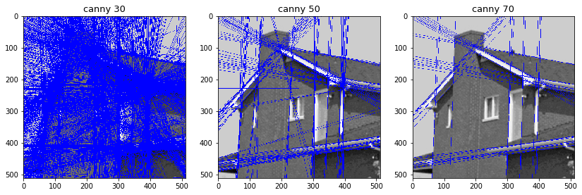

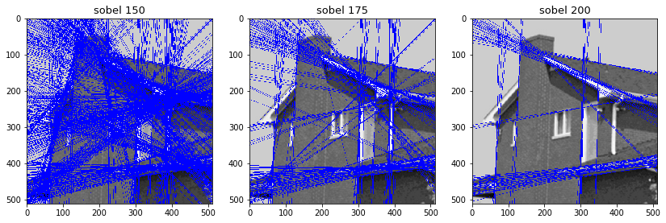

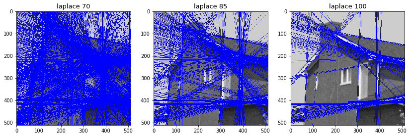

```python
def draw(name,img, index1, img1, index2, img2, index3):
    plt.figure(figsize = (14,14))
    p = plt.subplot(131)
    p.set_title(name+index1, fontsize = 13)
    p.imshow(img,cmap = 'gray')
    p1 = plt.subplot(132)
    p1.set_title(name+index2, fontsize = 13)
    p1.imshow(img1,cmap='gray')
    p2 = plt.subplot(133)
    p2.set_title(name+index3, fontsize = 13)
    p2.imshow(img2,cmap='gray')

path_name = '../../homework7/project/'
imagename = path_name + 'test1.tif'
tool = basic_cv_tool(imagename)
draw('canny ',tool.houghprocess('canny',imagename,30),str(30),tool.houghprocess('canny',imagename,50),str(50),tool.houghprocess('canny',imagename,70),str(70) )
draw('sobel ',tool.houghprocess('sobel',imagename,150),str(150),tool.houghprocess('sobel',imagename,175),str(175),tool.houghprocess('sobel',imagename,200),str(200) )
draw('laplace ',tool.houghprocess('laplace',imagename,70),str(70),tool.houghprocess('laplace',imagename,85),str(85),tool.houghprocess('laplace',imagename,100),str(100) )
```

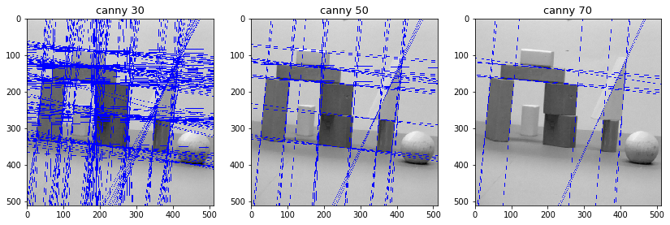

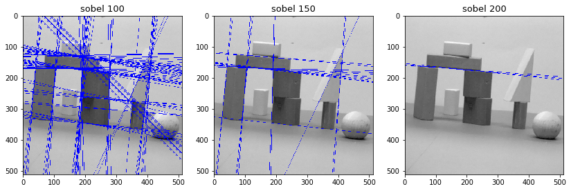

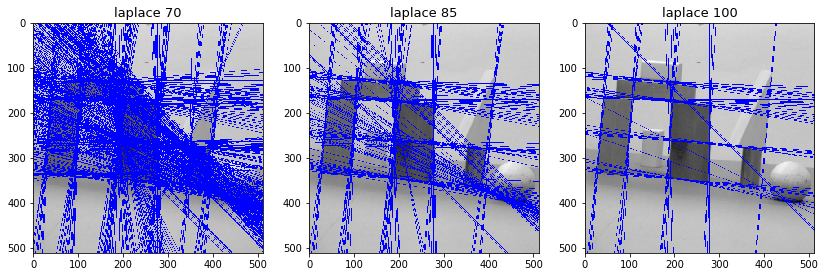

```python
imagename = 'test2.png'
imagename = path_name + imagename
tool = basic_cv_tool(imagename)
draw('canny ',tool.houghprocess('canny',imagename,30),str(30),tool.houghprocess('canny',imagename,50),str(50),tool.houghprocess('canny',imagename,70),str(70) )
draw('sobel ',tool.houghprocess('sobel',imagename,100),str(100),tool.houghprocess('sobel',imagename,150),str(150),tool.houghprocess('sobel',imagename,200),str(200) )
draw('laplace ',tool.houghprocess('laplace',imagename,70),str(70),tool.houghprocess('laplace',imagename,85),str(85),tool.houghprocess('laplace',imagename,100),str(100) )
```

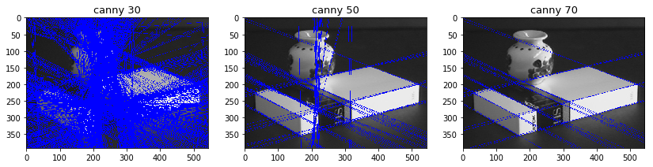

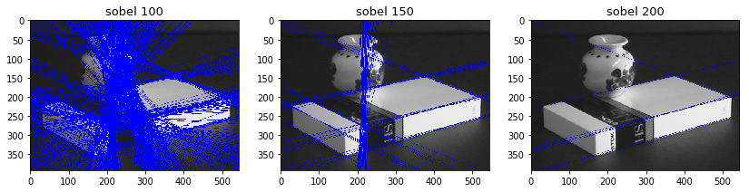

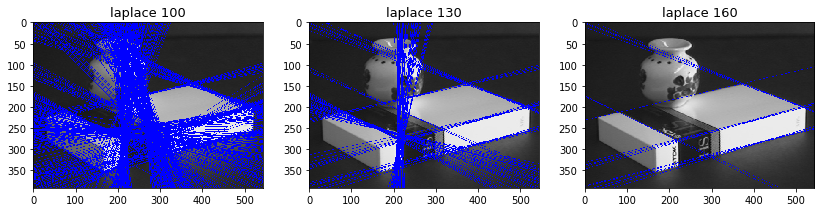

```python
imagename = 'test3.jpg'
imagename = path_name + imagename
tool = basic_cv_tool(imagename)
draw('canny ',tool.houghprocess('canny',imagename,30),str(30),tool.houghprocess('canny',imagename,50),str(50),tool.houghprocess('canny',imagename,70),str(70) )
draw('sobel ',tool.houghprocess('sobel',imagename,100),str(100),tool.houghprocess('sobel',imagename,150),str(150),tool.houghprocess('sobel',imagename,200),str(200) )
draw('laplace ',tool.houghprocess('laplace',imagename,100),str(100),tool.houghprocess('laplace',imagename,130),str(130),tool.houghprocess('laplace',imagename,160),str(160) )
```

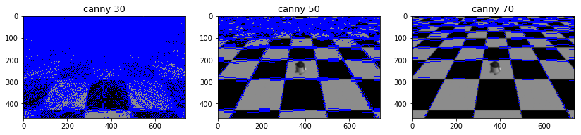

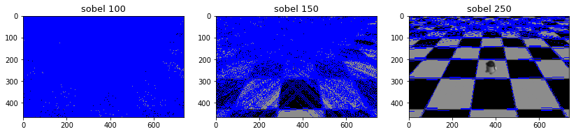

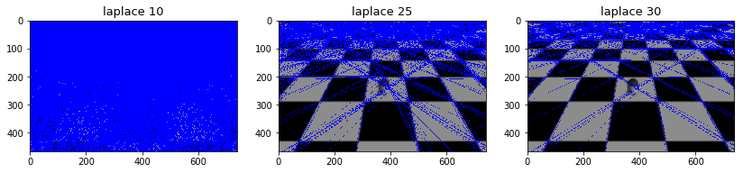

```python
imagename = 'test4.bmp'
imagename = path_name + imagename
tool = basic_cv_tool(imagename)
draw('canny ',tool.houghprocess('canny',imagename,30),str(30),tool.houghprocess('canny',imagename,50),str(50),tool.houghprocess('canny',imagename,70),str(70) )
draw('sobel ',tool.houghprocess('sobel',imagename,100),str(100),tool.houghprocess('sobel',imagename,150),str(150),tool.houghprocess('sobel',imagename,250),str(250) )
draw('laplace ',tool.houghprocess('laplace',imagename,10),str(10),tool.houghprocess('laplace',imagename,25),str(25),tool.houghprocess('laplace',imagename,30),str(30) )
```

## 实验结论

通过以上对比试验，我们发现Canny在实验过程中表现出较优秀的效果，不同的图片展示出来的参数效果也具有十分稳定的效果。其他两个算子由于效果不是很理想，故采用了二值化的处理方法，但是代价就是对不同的图片需要动态调整参数，才能达到满意的效果。而这里sobel算子的稳定性优于Laplace算子。